# Project Foundations for Data Science: FoodHub Data Analysis

### **Question 12**: Perform a multivariate analysis to explore relationships between the important variables in the dataset. (It is a good idea to explore relations between numerical variables as well as relations between numerical and categorical variables) [10 marks]

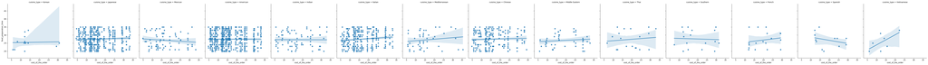

```python
# lmplot shows us the distribution with kde, by cuisine type
sns.lmplot(data=df , x = 'cost_of_the_order' , y = 'food_preparation_time' , col='cuisine_type')
plt.show()
```

#### Observation: I was curious as to whether a higher order cost would increase the amount of time it took to prepare the food because I assumed a higher order cost would mean more food to prepare. However, it doesn't look like such a relationship exists with most cuisine types. It seems that no matter what the cost of the order, the time it takes to prepare the order has a lot of range.

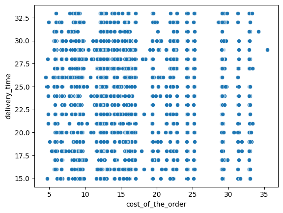

```python
#scatterplot to see if cost and delivery time are correlated
sns.scatterplot(data=df , x = 'cost_of_the_order' , y = 'delivery_time')
plt.show()
```

#### Observation: Since there doesn't seem to be a relationship between preparation time and order cost, I was curious to see if the delivery time (which may be an indicator of distance) had any influence on order cost. Again, we can see that there is no relationship between the two. From the heatmap below, we can see that there is truly no correlation between any combination of the numerical variables.

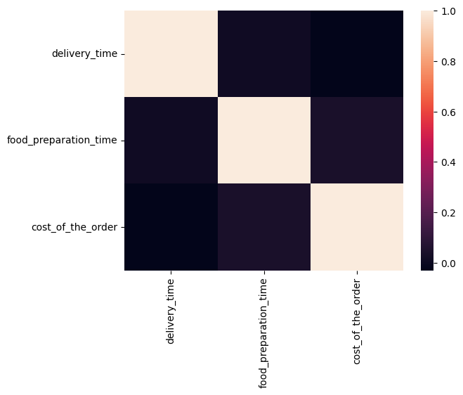

```python
#checking to see if a correlation exists between delivery time, food prep time and cost
sns.heatmap(data=df[['delivery_time','food_preparation_time','cost_of_the_order']].corr());
```

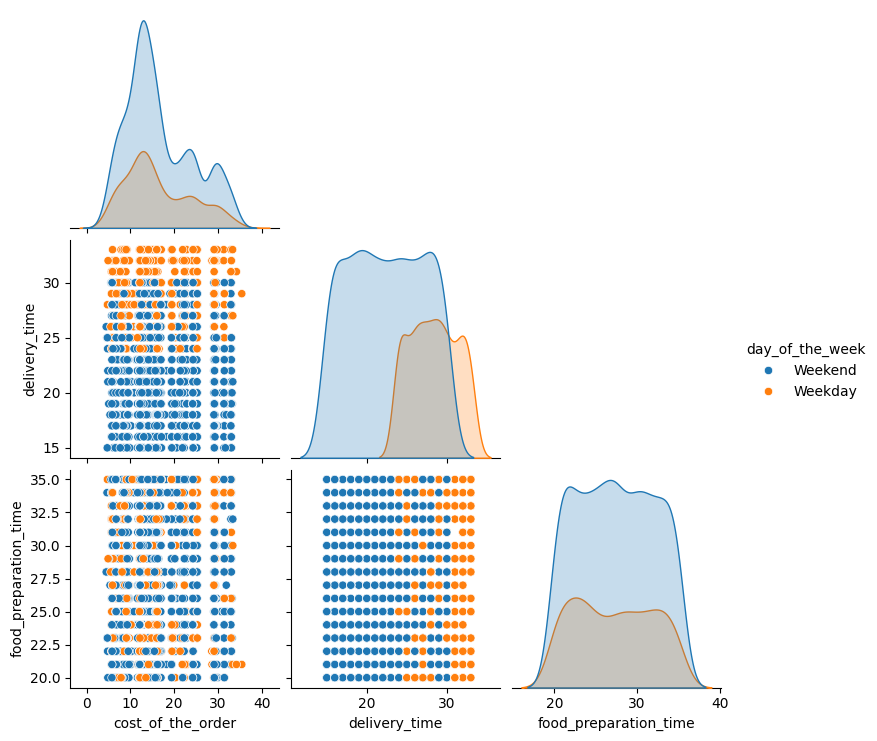

```python
#pairplots can show us relationships between multiple variables and hue/color can be used to categorize
sns.pairplot(data=df, vars=['cost_of_the_order', 'delivery_time','food_preparation_time'], hue='day_of_the_week', corner=True);
plt.show()
```

#### Observations: While the above pairplots do still support the fact that there doesn't seem to be a direct relationship between delivery time or food preparation time with order cost, they also show us some new information regarding day of the week. It seems weekday orders take longer to deliver. In the below strip plot, we can see further evidence of this.

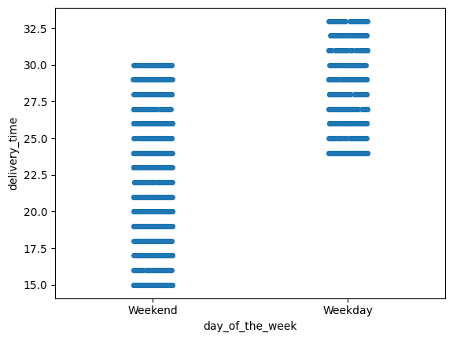

```python
#strip plots are good for checking where most of the data points are when checking a correlation between categorical and numerical variables
#verifying relationship between day of week and delivery time
sns.stripplot(data=df, x='day_of_the_week', y='delivery_time', jitter = True)
plt.show()
```

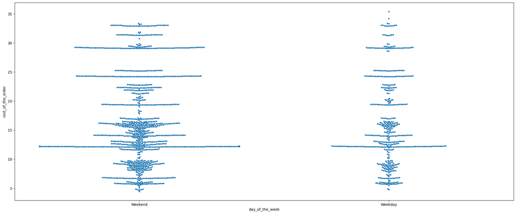

```python
#swarm plots can show us the same relationships as strip plots but with the data points spread out to see the number of them more easily
# checking to see if there is a relationship between day of week and cost of order
plt.figure(figsize=(25,10))
sns.swarmplot(data=df, x='day_of_the_week', y='cost_of_the_order', s = 4)
plt.show()
```

#### Observation: There is a higher number of orders on the weekend than on weekdays, but the cost distribution seems to be the same for both.

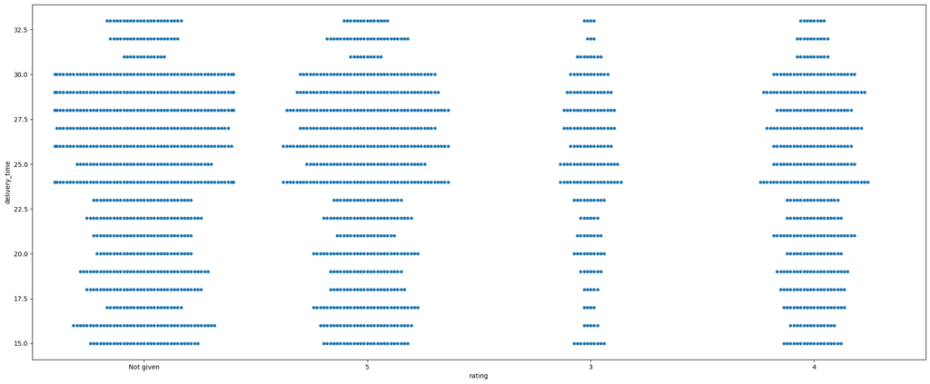

```python
#checking if there is a relationship between rating and delivery time
plt.figure(figsize=(25,10))
sns.swarmplot(data=df, x='rating', y='delivery_time')
plt.show()
```

#### Observations: There seems to be a higher concentration of 4 and 5 star ratings in the lower part of the above graph than there are 3 star ratings, indicating the deliveries with lower delivery times receive better ratings.

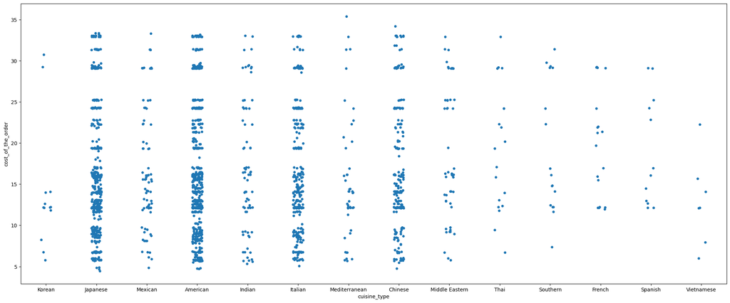

```python
#checking to see if there is a relationship between cuisine type and cost of the order
plt.figure(figsize=(25,10))
sns.stripplot(data=df, x='cuisine_type', y='cost_of_the_order')
plt.show()
```

#### Observations: Orders for Vietnamese cuisine seem to be of the lowest costs, and most of the orders on the higher end of the cost spectrum are of the American, Japanese, Chinese and Italian cuisine type. Not only do these cuisine types bring in a higher number of orders, but they also bring in higher costs per order for the most part.

### **Question 13:** The company wants to provide a promotional offer in the advertisement of the restaurants. The condition to get the offer is that the restaurants must have a rating count of more than 50 and the average rating should be greater than 4. Find the restaurants fulfilling the criteria to get the promotional offer. [3 marks]

```python
# Write the code here
# creating a variable using arguments to print a list of restaurants having more than 50 ratings and an average of more than 4
df_rated = df[df['rating'] != 'Not given']
df_rated['rating'] = df_rated['rating'].astype(float)
restaurant_ratings = df_rated.groupby('restaurant_name')['rating'].agg(['count', 'mean'])
promotional_restaurants = restaurant_ratings[(restaurant_ratings['count'] > 50) & (restaurant_ratings['mean'] > 4)]
print(promotional_restaurants)
```

```
                           count      mean
restaurant_name
Blue Ribbon Fried Chicken     64  4.328125
Blue Ribbon Sushi             73  4.219178
Shake Shack                  133  4.278195
The Meatball Shop             84  4.511905
```

#### Observations: There are four restaurants that will get the promotional offer: Blue Ribbon Fried Chicken with 64 ratings averaging 4.33, Blue Ribbon Sushi with 73 ratings averaging 4.22, Shake Shack with 133 ratings averaging 4.28 and the Meatball Shop with 84 ratings averaging 4.51.

### **Question 14:** The company charges the restaurant 25% on the orders having cost greater than 20 dollars and 15% on the orders having cost greater than 5 dollars. Find the net revenue generated by the company across all orders. [3 marks]

```python
# Write the code here
# creating an elif loop to define a new variable revenue and calulate the total
def revenue(s):
  if s > 20:
    return s * .25
  elif s > 5:
    return s * .15
  else:
    return 0
df['revenue']=df['cost_of_the_order'].apply(revenue)
print("The net revenue generated by the company across all orders is $", int(sum(df['revenue'])))
```

```
The net revenue generated by the company across all orders is $ 6166
```

#### Observations: The net revenue generated by the company across all orders is $ 6166.30, which I chose to round to the nearest whole dollar.

### **Question 15:** The company wants to analyze the total time required to deliver the food. What percentage of orders take more than 60 minutes to get delivered from the time the order is placed? (The food has to be prepared and then delivered.) [2 marks]

```python
# Write the code here
# # couting the orders which took longer than 60 minutes and then dividing by the total count of first column (index 0) to get percentage
df['total_time']=df['food_preparation_time']+df['delivery_time']
round(df[df['total_time']>60].shape[0]/df.shape[0]*100,2)
```

```
10.54
```

#### Observations: 10.54% of the orders take more than 60 minutes to get delivered from the time the order is placed.

### **Question 16:** The company wants to analyze the delivery time of the orders on weekdays and weekends. How does the mean delivery time vary during weekdays and weekends? [2 marks]

```python
# Write the code here
# grouping the delivery times by day of week and using the statistical function .mean() to calculate the average for each
df.groupby(['day_of_the_week'])['delivery_time'].mean()
```

```
day_of_the_week
Weekday    28.340037
Weekend    22.470022
Name: delivery_time, dtype: float64
```

#### Observations: The average delivery time for orders placed on weekdays (28.34 minutes) is longer than the average delivery time for orders placed on weekends (22.47 minutes).

### Conclusion and Recommendations

### **Question 17:** What are your conclusions from the analysis? What recommendations would you like to share to help improve the business? (You can use cuisine type and feedback ratings to drive your business recommendations.) [6 marks]

### Conclusions:

- The most popular type of cuisine sold through FoodHub is American cuisine, followed by Japanese, Italian and Chinese.
- There are many orders that do not have any ratings, but the ones that do have ratings seem to mostly be impacted by delivery times.
- No ratings are under 3, which indicates FoodHub is performing well and most users are pleased with the application.
- Shake Shack and the Meatball Shop are the most popular restaurants in terms of number of orders.
- Delivery times for orders placed on weekdays are longer on average than delivery times for orders placed on weekends.
- A majority of orders placed are on the lower end of the cost spectrum, averaging around $12.
- More orders are placed on the weekend than on weekdays.

### Recommendations:

- Being that American cuisine is the most popular cuisine ordered through FoodHub, promotions and advertising can be focused on American restaurants and food. Other popular cuisine types that can be promoted similarly are Japanese, Italian and Chinese.
- These popular cuisine types also bring in most of the orders on the higher end of the cost spectrum. Reaching out to owners of restaurants with these popular types of cuisines and encouraging them to sign up on the platform will be the most profitable.
- The average times are longer on the weekdays than they are on the weekends, indicating a possible need for more drivers during the weekdays.
- Encourage and remind users to leave a rating for their deliveries so more data can be obtained regarding what makes for a positive customer experience.
- Consider pricing structures that encourage more restaurants to sign up for FoodHub in order to sustain long-term profitability.